# 柳海娇-SA19017054-程序作业9&10

柳海娇

2019/11/2

# lec9

## Question

1. 对R中的数据集faithful,使用正态混合模型估计eruptions和waiting的联合密度函数,写出你的EM算法,并与mixtools包中的normalmiEM函数对比.

## Solution

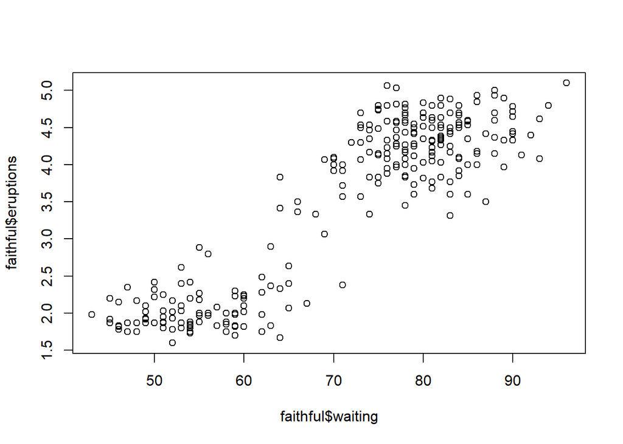

```r
data(faithful)
plot(faithful$waiting,faithful$eruptions)

x<-as.matrix(faithful)
n<-nrow(faithful)

f <- function(x,m,s) ((2*pi)^(-n/2)/sqrt(det(s))*exp(-t(x-m)%*%solve(s)%*%(x-m)/2))
 #to get the pdf of x

probs <- c(0.5, 0.5)
mu <- matrix(c(2,55,4.5,80),2,byrow = TRUE)
sigma <- matrix(c(1,0,0,1,1,0,0,1),4,byrow = TRUE)
Z<-matrix(rep(0,2*n),n)

for (l in 1:50) {

}
  for (j in 1:n) {
    for (i in 1:2) {
      Z[j,i]<-probs[i]*f(x[j,],mu[i,],sigma[(2*i-1):(2*i),])
    }
    Z[j,]<-Z[j,]/sum(Z[j,])
  }

  probs<-colMeans(Z) # update probs of the mixture component

  for (i in 1:2) {
    mu[i,]=t(Z[,i])%*%x/sum(Z[,i]) # update mu
    sig.s=Z[1,i]*(x[1,]-mu[i,])%*%t(x[1,]-mu[i,])
    for (j in 2:n) {
      sig.s=sig.s+Z[j,i]*(x[j,]-mu[i,])%*%t(x[j,]-mu[i,])
    }
    sigma[(2*i-1):(2*i),]=sig.s/sum(Z[,i]) # update sigma
  }
library(mixtools)
```

```r
print('mu:');mu
print('mu(mixtools)');normalmixEM(x[,1])$mu;normalmixEM(x[,2])$mu
print('mixture sigma:');sigma
print('sigma(mixtools)');normalmixEM(x[,1])$sigma^2;normalmixEM(x[,2])$sigma^2
print('probs=:');probs
```

```
## [1] "mu:"
##         [,1]     [,2]
## [1,] 2.09433 54.75000
## [2,] 4.29793 80.28488
## [1] "mu(mixtools)"
## number of iterations= 23
## [1] 2.018609 4.273345
## number of iterations= 23
## [1] 54.61481 80.09104
## [1] "mixture sigma:"
##           [,1]       [,2]
## [1,] 0.1542787  0.9856630
## [2,] 0.9856630 34.4075040
## [3,] 0.1776172  0.7631011
## [4,] 0.7631011 31.4827928
## [1] "sigma(mixtools)"
## number of iterations= 32
## [1] 0.05551819 0.19102324
## number of iterations= 35
## [1] 34.47155 34.43006
## [1] "probs=:"
## [1] 0.3676471 0.6323529
```

## Question

2.利用FNN包中knn.dist函数写一个密度估计函数, 并对1中的数据进行k近邻密度估计.

# lec10

## Question 1

1. 对R中的数据集faithful,分别使用乘积和和球对称核估计eruptions和waiting的联合密度函数,考虑不同带宽选择方法.

## Solution 1

```r
library(np)
data("faithful")
x<-as.matrix(faithful)

f.faithful <- npudens(~ eruptions + waiting, data = faithful)
```

[output not shown]

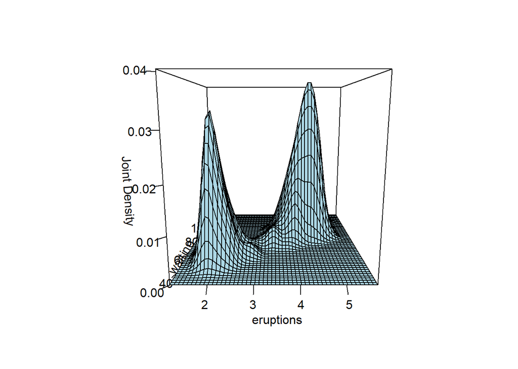

```r
plot(f.faithful, xtrim = -0.2,view="fixed",main = "")
```

```r
#generalized nearest neighbors
bw<-npudensbw(~ eruptions + waiting, data = faithful,bwtype="generalized_nn")
```

[output not shown]

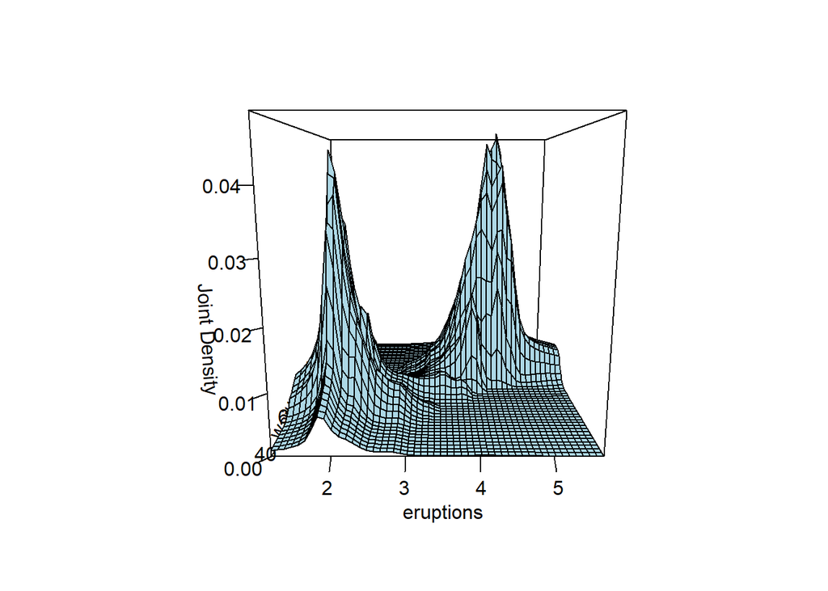

```r
f.d<- npudens(bw)
plot(f.d, xtrim = -0.2, view = "fixed", main = "")
```

```r
# adaptive nearest neighbors bandwidth
bw<-npudensbw(~ eruptions + waiting, data = faithful,bwtype="adaptive_nn")
```

[output not shown]

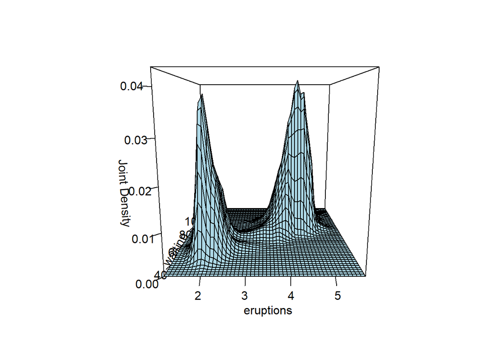

```r
f.d<- npudens(bw)
plot(f.d, xtrim = -0.2,view = "fixed", main = "")
```

## Question 3

3.对wines数据, 去除类别变量vintage并标准化变量,然后进行PCA.利用基于密度估计的聚类方法（参考附录cluster.R），  
(1) 使用3个主成分可以发现几个类?如果min.clust.size变量被设置为最小类至少包含5%的数据，结果会如何？结果对min.clust.size的值敏感吗？  
(2) 使用相同的min.clust.size值，使用6个主成分，能够发现几个类？使用两两散点图识别有助于聚类的主成分，以及没有帮助的主成分。  
(3) 使用两个主成分进行聚类，可以发现几个类？比较2个主成分和3个主成分的结果。  
(4) 比较聚类结果和真实的类别。  
(5) 对比kmeans聚类算法下k=3，4的结果。

## Solution 3

```r
data1<-read.delim("C:\\Users\\10127\\Desktop\\wines.txt",header = TRUE)
data1 <- subset(data1, select = -vintage )
data2<-as.matrix(data1)
x<-scale(data2, center = TRUE, scale = TRUE)
library(ks)

x.pca<-princomp(x,cor = T)

#三个主成分
x_3<-as.data.frame(x.pca$scores[,1:3])
H <- ks::Hpi(x = x_3, deriv.order = 1)
kms <- ks::kms(x = x_3, H = H)
kms$nclust # Number of clusters found
```

```
## [1] 6
```

```r
#min.clust.size变量被设置为最小类至少包含5%的数据
kms <- ks::kms(x = x_3, H = H, min.clust.size =nrow(x)*0.05)
kms$nclust # Number of clusters found
```

```
## [1] 5
```

使用3个主成分可以发现6个类,如果min.clust.size变量被设置为最小类至少包含5%的数据，则只能发现5个类.结果对min.clust.size的值敏感  
(2)

```r
#六个主成分
x_6<-as.data.frame(x.pca$scores[,1:6])
H <- ks::Hpi(x = x_6)
kms <- ks::kms(x = x_6, H = H, keep.path = TRUE,min.clust.size =nrow(x)*0.05)
kms$nclust # Number of clusters found
```

```
## [1] 11
```

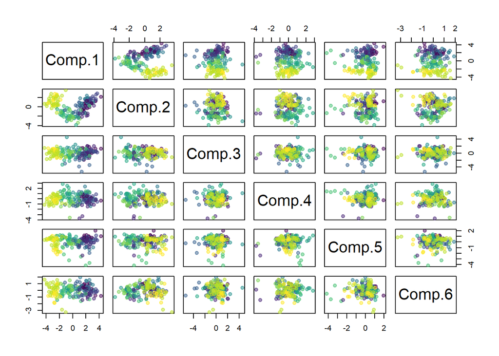

```r
cols <- viridis::viridis(kms$nclust, alpha = 0.5)[kms$label]
plot(x_6, col = cols, pch = 19)
for (i in 1:nrow(x_6)) lines(kms$path[[i]], col = cols[i])
points(kms$mode, pch = 8, cex = 2, lwd = 2)
```

此时有11个类  
(3)

```r
x_2<-as.data.frame(x.pca$scores[,1:2])
H <- ks::Hpi(x = x_2, deriv.order = 1)
kms <- ks::kms(x = x_2, H = H, keep.path = TRUE)
kms$nclust # Number of clusters found
```

```
## [1] 4
```

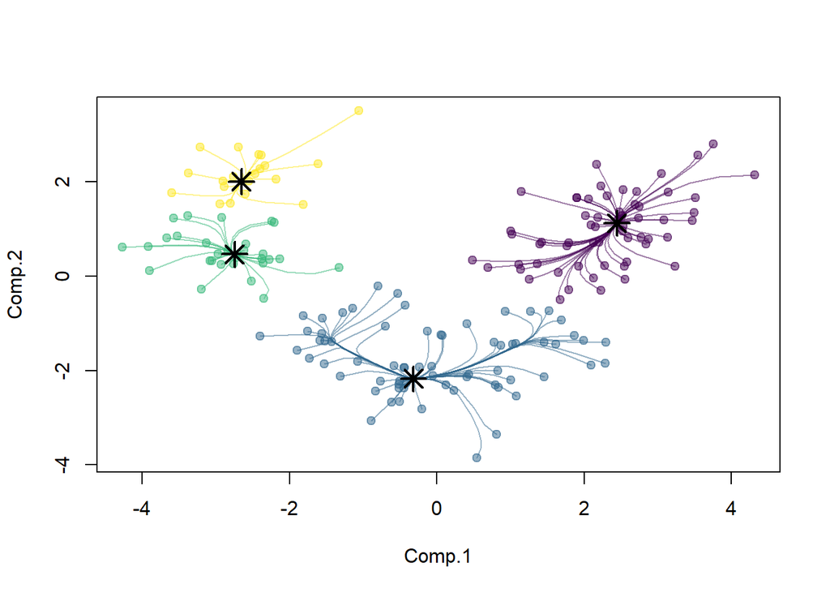

```r
cols <- viridis::viridis(kms$nclust, alpha = 0.5)[kms$label]
plot(x_2, col = cols, pch = 19)
for (i in 1:nrow(x_2)) lines(kms$path[[i]], col = cols[i])
points(kms$mode, pch = 8, cex = 2, lwd = 2)
```

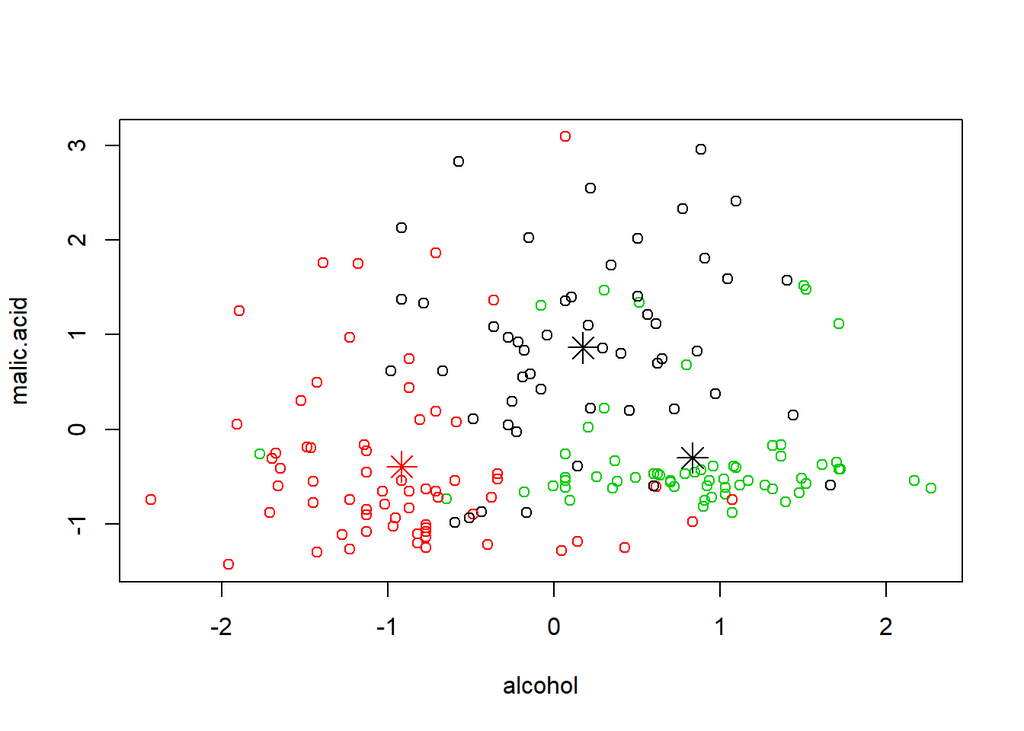

```r
k.3 <- kmeans(x, 3)
plot(x, col = k.3$cluster)
points(k.3$centers, col = 1:2, pch = 8, cex = 2)
```

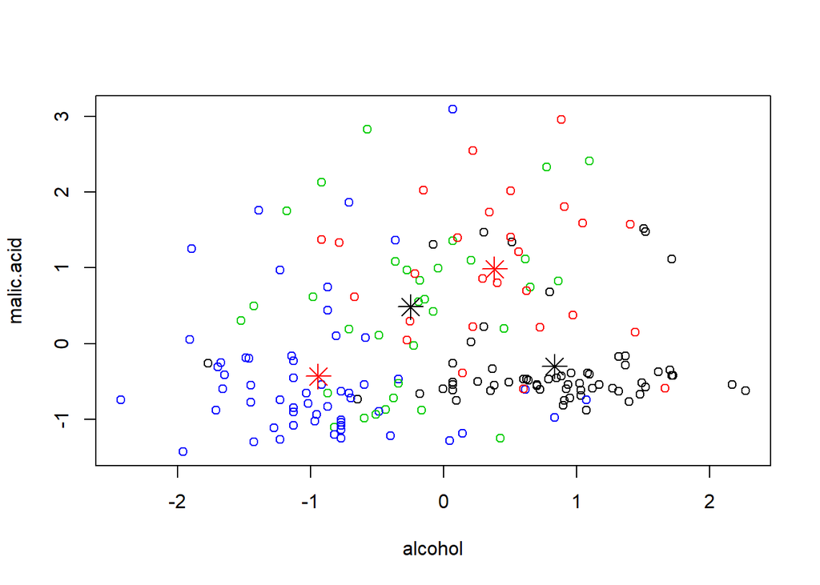

```r
k.4 <- kmeans(x, 4)
plot(x, col = k.4$cluster)
points(k.4$centers, col = 1:2, pch = 8, cex = 2)
```